# Quantitative Datenanalyse

18. Mai 2020

## Lernziele

- Konzept der Unsicherheit von Hypothesen verstehen
- Verständnis von Wahrscheinlichkeitstheorie auf t-Test anwenden können

## Ablauf

### Diese Sitzung

- Rückblick
- R (Code)
- Punkt- & Verteilungshypothesen
- t-Test

## Letzte Sitzung

- Falsifizierbarkeit & Informationsgehalt theoretischer Aussagen
- Definition Bayes Factor, Punkt- & Verteilungshypothesen
- Übung zum Bayes Factor

## Falsifizierbarkeit & Informationsgehalt

### theoretischer Aussagen

“Wenn gewalthaltige digitale Spiele genutzt werden, dann zeigen sich verstärkt aggressive Gedanken.”

“Wenn gewalthaltige digitale Spiele genutzt werden, dann zeigen sich verstärkt aggressive Gedanken oder aggressive Verhaltensweisen.”

## Falsifizierbarkeit & Informationsgehalt

### theoretischer Aussagen

“Personen, die das Medikament LH einnehmen, haben eine **andere** Schlafdauer als Personen, die das Medikament nicht einnehmen.”

“Personen, die das Medikament LH einnehmen, haben eine **größere** Schlafdauer als Personen, die das Medikament nicht einnehmen.”

“Personen, die das Medikament LH einnehmen, schlafen durschnittlich **30 Minuten länger** als Personen, die das Medikament nicht einnehmen.”

“Personen, die das Medikament LH einnehmen, schlafen durschnittlich **ca. 30 Minuten länger** als Personen, die das Medikament nicht einnehmen.”

“Personen, die das Medikament LH einnehmen, schlafen durschnittlich **ca. 30-40 Minuten länger** als Personen, die das Medikament nicht einnehmen.”

## Beispiele

- 3-maliger Münzwurf: Wie oft kommt Kopf?
- Anteil der G9-Befürworter in der Population?

Siehe App:  
https://shiny.jschn.org/qda-ss2020/4_Sitzung/bf.Rmd

## R

## R

### Code How-To Wiederholung

**Funktionen**

```r
t.test()
```

**Argumente**

```r
t.test(formula = extra ~ group,
       data = sleep
       )
```

```r
t.test(formula = extra ~ group,
       data = sleep,
       alternative = "greater",
       var.equal = TRUE
       )
```

## R

### Code How-To Wiederholung

**Objekte**

```r
ein_Ergebnis <- 2 + 5
ein_Text <- "Das wird gespeichert"
ein_Datensatz <- data.frame(x = c(1,2,3,4,5),
                            y = c("A", "B", "C", "D", "E"))
ein_Datensatz
```

```
##   x y
## 1 1 A
## 2 2 B
## 3 3 C
## 4 4 D
## 5 5 E
```

```r
Ergebnis_ttest <- t.test(formula = extra ~ group,
                         data = sleep,
                         alternative = "greater",
                         var.equal = TRUE
                         )
```

## R

### Code How-To Wiederholung

**Kommentare**

```r
# t-Test für unabhängige Stichproben
# Gruppe 1= KG, Gruppe 2= EG
# AV: Differenz der Schlafdauer
t.test(formula = extra ~ group,
       data = sleep,                 # Student's sleep data (1908)
       # alternative = "greater",
       var.equal = TRUE
       )
```

## Punkt- & Verteilungshypothesen

## unsere Daten

```r
# Simulation von Daten
# mit Mittelwert 100, SD = 10
mittel_diff <- 30    # Hier Ihren gewünschten Mittelwertsunterschied eingeben

ttest_data <- data.frame(schlafdauer = c(rnorm(n = 10,
                                               mean = 480,
                                               sd = 30),
                                         rnorm(n = 10,
                                               mean = 480 + mittel_diff,
                                               sd = 30)),
                         gruppe = as.factor(c(rep("Kontrollgruppe", 10),
                                              rep("Experimentalgruppe", 10))))

ttest_data
```

```
##    schlafdauer             gruppe
## 1     467.4468     Kontrollgruppe
## 2     514.4679     Kontrollgruppe
## 3     511.4981     Kontrollgruppe
## 4     521.7325     Kontrollgruppe
## 5     484.7836     Kontrollgruppe
## 6     480.8363     Kontrollgruppe
## 7     470.0546     Kontrollgruppe
## 8     508.1544     Kontrollgruppe
## 9     431.6287     Kontrollgruppe
## 10    469.8008     Kontrollgruppe
## 11    457.3638 Experimentalgruppe
## 12    509.1386 Experimentalgruppe
## 13    506.6419 Experimentalgruppe
## 14    508.7911 Experimentalgruppe
## 15    507.3272 Experimentalgruppe
## 16    520.8220 Experimentalgruppe
## 17    545.8105 Experimentalgruppe
## 18    493.5049 Experimentalgruppe
## 19    601.9194 Experimentalgruppe
## 20    533.1668 Experimentalgruppe
```

## unsere Daten

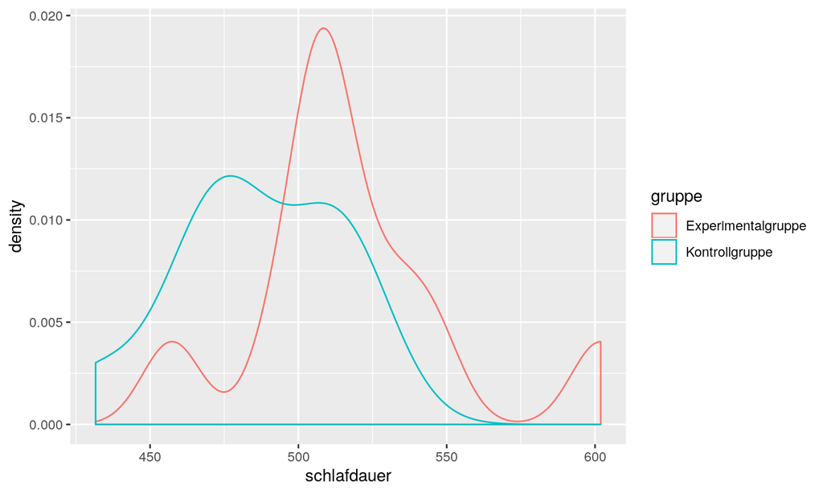

```r
ggplot(ttest_data, aes(x=schlafdauer, group = gruppe, color = gruppe)) +
  geom_density()
```

## Punkthypothese \(H_0\): t-Verteilung

**Dichtefunktion \(H_0\)**

```r
freiheitsgrade <- 18
t1_data <- data.frame(t = rt(n = 100000,
                             df=freiheitsgrade
                             )
                      )
head(t1_data)
```

```
##            t
## 1 -0.6673832
## 2 -0.8553685
## 3 -1.6218282
## 4 -1.6473089
## 5 -0.4395086
## 6  0.2505262
```

## Punkthypothese \(H_0\): t-Verteilung

```r
t_krit <- qt(0.95, 18)
t_krit
```

```
## [1] 1.734064
```

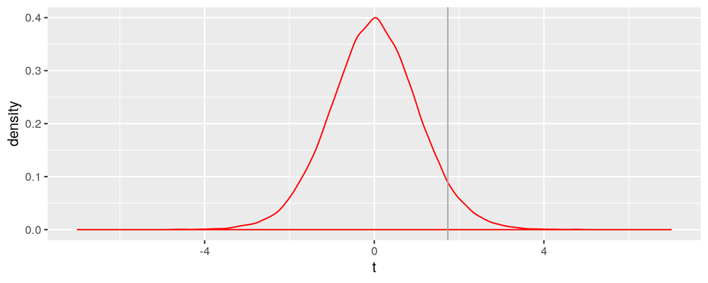

```r
ggplot(t1_data, aes(x=t)) +
  geom_density(color = "red") +
  scale_x_continuous(limits = c(-7,7)) +
  geom_vline(xintercept = t_krit, color = "darkgrey")
```

## Punkthypothesen \(H_0\) & \(H_1\)

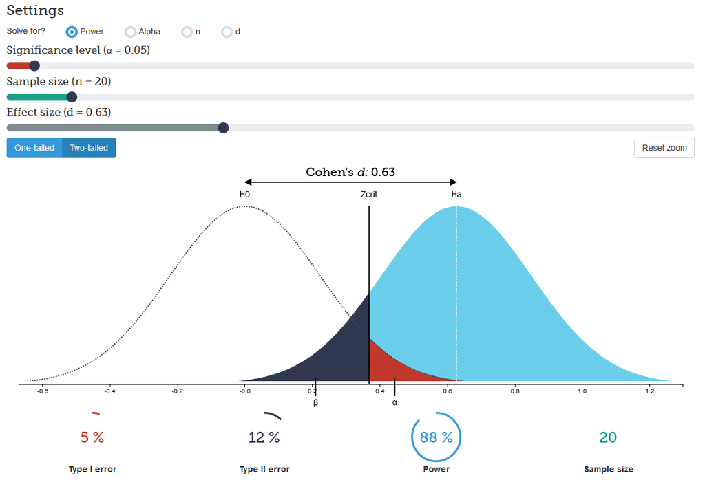

## Verteilungshypothesen

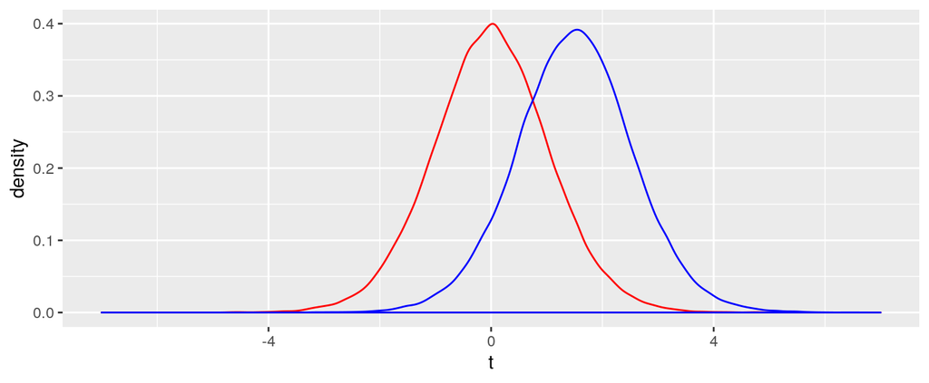

```r
# Hypothesentesten anhand Bayes-Faktoren: Vergleich von Hypothesen
mu <- 1.5 # Veränderung des mittleren Effekts (=Punkthypothese)

t2_data <- data.frame(t = rt(n = 100000,
                             df=freiheitsgrade
                             ) + mu
                      )
ggplot(t1_data, aes(x=t)) +
  geom_density(color = "red") +
  geom_density(aes(x=t2_data$t), color = "blue") +
  scale_x_continuous(limits = c(-7,7))
```

## Verteilungshypothesen

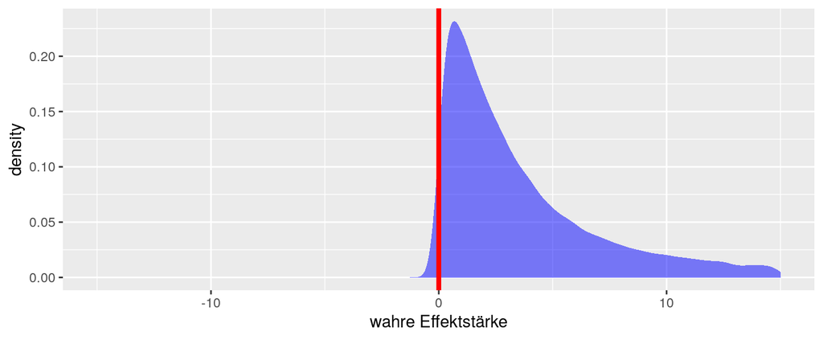

```r
verteilungshyp <- data.frame(t = rcauchy(n = 100000,
                             location = 0,
                             scale = 3)) %>%
                       dplyr::filter(t>=0)

ggplot(verteilungshyp, aes(x=t)) +
  geom_density(color = NA, fill = "blue", alpha = .5) +
  scale_x_continuous(limits = c(-15,15)) +
  geom_vline(xintercept = 0, size = 1.5, color = "red") +
  xlab("wahre Effektstärke")
```

## Verteilungshypothesen

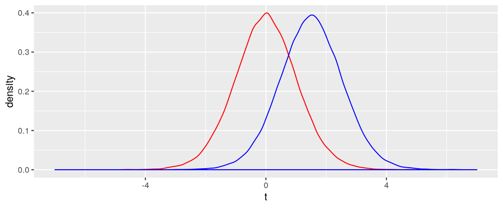

```r
mu <- 1.5 # Veränderung des mittleren Effekts (=Punkthypothese)


t2_data <- data.frame(t = rt(n = 100000,
                             df=freiheitsgrade
                             ) + mu
                      )
ggplot(t1_data, aes(x=t)) +
  geom_density(color = "red") +
  geom_density(aes(x=t2_data$t), color = "blue") +
  scale_x_continuous(limits = c(-7,7))
```

## Verteilungshypothesen

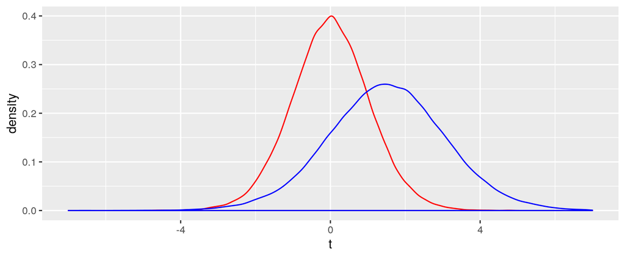

```r
mu <- 1.5 # Veränderung des mittleren Effekts (=Punkthypothese)
s <- 1.5  # Unsicherheit der Schätzung

t2_data <- data.frame(t = rt(n = 100000,
                             df=freiheitsgrade
                             ) *s + mu
                      )
ggplot(t1_data, aes(x=t)) +
  geom_density(color = "red") +
  geom_density(aes(x=t2_data$t), color = "blue") +
  scale_x_continuous(limits = c(-7,7))
```

## t-Test

## t-Test (frequentistisch)

```r
ttest_erg_f <- t.test(formula = schlafdauer ~ gruppe,
                      data = ttest_data,
                      var.equal = TRUE,
                      alternative = "greater"
                      )

ttest_erg_f
```

```
##
##  Two Sample t-test
##
## data:  schlafdauer by gruppe
## t = 2.1845, df = 18, p-value = 0.0212
## alternative hypothesis: true difference in means is greater than 0
## 95 percent confidence interval:
##  6.682501      Inf
## sample estimates:
## mean in group Experimentalgruppe     mean in group Kontrollgruppe
##                         518.4486                         486.0404
```

## t-Test (frequentistisch)

### t-Verteilung

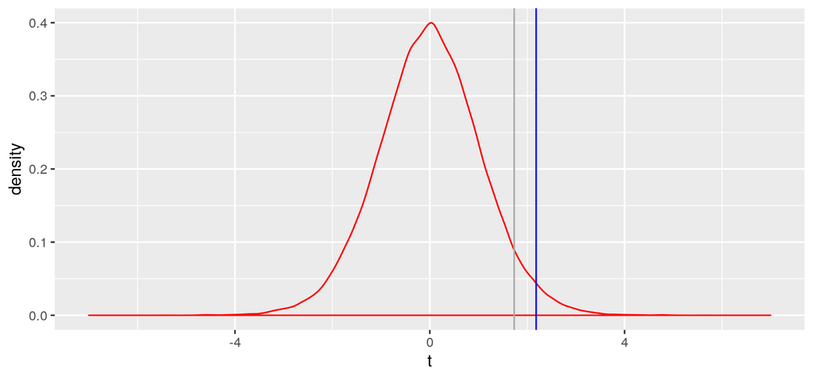

```r
ggplot(t1_data, aes(x=t)) +
  geom_density(color = "red") +
  scale_x_continuous(limits = c(-7,7)) +
  geom_vline(xintercept = t_krit, color = "darkgrey") +
  geom_vline(xintercept = ttest_erg_f$statistic, color = "blue")
```

## t-Test (bayesianisch)

```r
ttest_erg_bf <- ttestBF(formula = schlafdauer ~ gruppe,
                        data = ttest_data,
                        nullInterval = c(0, Inf), # Intervall der Verteilungshyp
                        rscale  = "medium"        # Unsicherheit: "medium", "wide", and "ultrawide"
                        )

ttest_erg_bf
```

```
## Bayes factor analysis
## --------------
## [1] Alt., r=0.707 0<d<Inf    : 3.63158   ±0%
## [2] Alt., r=0.707 !(0<d<Inf) : 0.1602572 ±0%
##
## Against denominator:
##   Null, mu1-mu2 = 0
## ---
## Bayes factor type: BFindepSample, JZS
```

## t-Test (bayesianisch)

### t-Verteilung

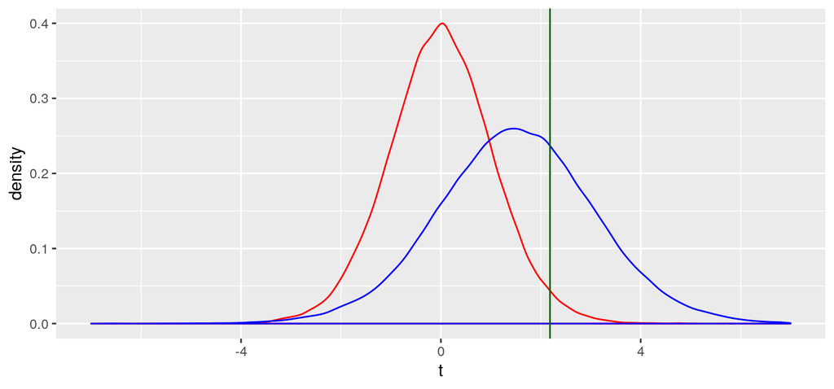

```r
ggplot(t1_data, aes(x=t)) +
  geom_density(color = "red") +
  geom_density(aes(x=t2_data$t), color = "blue") +
  scale_x_continuous(limits = c(-7,7)) +
  geom_vline(xintercept = ttest_erg_f$statistic, color = "darkgreen")
```